# AE 04: Mathematical Models

Songs on Spotify

**Important**

- Open [RStudio](https://rstudio.collegeofidaho.edu/) and create a subfolder in your AE folder called “AE-04”
- Go to the [Canvas](https://cofi.instructure.com/courses/17093/assignments/202833) and locate your `AE 04` assignment to get started.
- Upload the `ae-04.qmd` and `spotify-popular.csv` files into the folder you just created.

```r
library(tidyverse)
library(ggformula)
library(broom)
library(knitr)
library(patchwork) #arrange plots in a grid
```

## Data

The data set for this assignment is a subset from the [Spotify Songs](https://github.com/rfordatascience/tidytuesday/blob/master/data/2020/2020-01-21/readme.md) Tidy Tuesday data set. The data were originally obtained from Spotify using the **spotifyr** R package.

It contains numerous characteristics for each song. You can see the full list of variables and definitions [here](https://github.com/rfordatascience/tidytuesday/blob/master/data/2020/2020-01-21/readme.md). This analysis will focus specifically on the following variables:

| variable | class | description |
| --- | --- | --- |
| track_id | character | Song unique ID |
| track_name | character | Song Name |
| track_artist | character | Song Artist |
| track_popularity | double | Song Popularity (0-100) where higher is better |
| danceability | double | Danceability describes how suitable a track is for dancing based on a combination of musical elements including tempo, rhythm stability, beat strength, and overall regularity. A value of 0.0 is least … |
| energy | double | Energy is a measure from 0.0 to 1.0 and represents a perceptual measure of intensity and activity. Typically, energetic tracks feel fast, loud, and noisy. For example, death metal has high energy, whi… |
| loudness | double | The overall loudness of a track in decibels (dB). Loudness values are averaged across the entire track and are useful for comparing relative loudness of tracks. Loudness is the quality of a sound that… |
| valence | double | A measure from 0.0 to 1.0 describing the musical positiveness conveyed by a track. Tracks with high valence sound more positive (e.g. happy, cheerful, euphoric), while tracks with low valence sound mo… |
| tempo | double | The overall estimated tempo of a track in beats per minute (BPM). In musical terminology, tempo is the speed or pace of a given piece and derives directly from the average beat duration. |
| duration_ms | double | Duration of song in milliseconds |

```r
spotify <- read_csv("../data/spotify-popular.csv")
```

What makes a song danceable? To answer this question, we’ll analyze data on some of the most popular songs on Spotify, i.e. those with `track_popularity >= 80`. We’ll use linear regression to fit some models to predict a song’s `dancebility`. Each group will be assigned a different predictor variable.

### Predictor Assignment:

Below is your assigned predictor. Look at the table above for a definition.

- **Group 1:** `energy`
- **Group 2:** `loudness`
- **Group 3:** `valence`
- **Group 4:** `tempo`

## Exercise 0

Below are plots as part of the exploratory data analysis. Change `duration_ms` and the axis labels to match your explanatory variable.

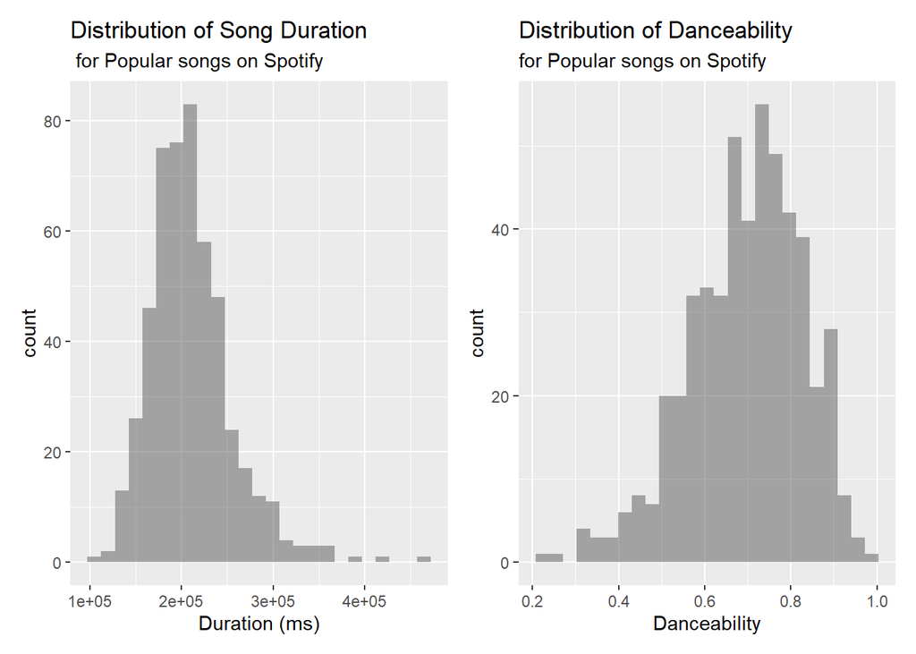

```r
p1 <- gf_histogram(~duration_ms, data = spotify) |>
  gf_labs(title = "Distribution of Song Duration",
       subtitle = " for Popular songs on Spotify",
       x = "Duration (ms)")

p2 <- gf_histogram(~danceability, data = spotify) |>
  gf_labs(title = "Distribution of Danceability",
       subtitle = "for Popular songs on Spotify",
       x = "Danceability")
p1 + p2 # The patchwork package will arrange your plots for you
```

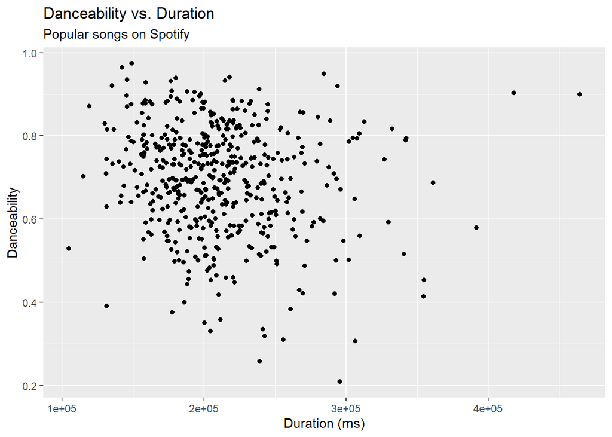

```r
gf_point(danceability ~ duration_ms, data = spotify) |>
  gf_labs(title = "Danceability vs. Duration",
       subtitle = "Popular songs on Spotify",
       x = "Duration (ms)",
       y = "Danceability")
```

## Exercise 1

Fit a model using your assigned explanatory variable to predict a songs `danceability`. Use `tidy` and `kable` to neatly display your model and have your reporter write you model on the white board. Be prepared to verbally interpret the slope.

```r
## add code
```

## Exercise 2

Write down the the null and alternative hypotheses to test whether your explanatory variable is a useful predictor.

## Exercise 3

Identify the standard error of $\hat{\beta}_1$ and your T-statistic from the output above. Interpret your test statistic. Do you think this provides evidence that your explanatory variable is a useful predictor of `danceability`?

## Exercise 4

Identify and interpret the p-value in the output from Exercise 1. On the white board, draw a sketch of your p-value.

## Exercise 5

Based on your p-value, how strong is the evidence that your assigned explanatory variable is a useful predictor of `danceability`?

## Exercise 6

Write a conclusion for your test in the context of the problem.

## Exercise 7

Use `tidy` to compute a (95 - your group number)% confidence interval for your slope.

## Exercise 8

On the white board, draw a picture representing the critical value for you confidence interval.

## Exercise 9

Interpret your confidence interval in the context of the problem.

## Exercise 10

Predict the average danceability for a song with:

- an energy score of 0.859
- a loudness score of -5.03
- a valence of 0.52
- a tempo of 125

Report and interpret a 90% confidence interval for the average danceability. Have your reporter write you interval and estimate on the board.

## Exercise 11

Report and interpret a 90% confidence interval for a single song with:

- an energy score of 0.859
- a loudness score of -5.03
- a valence of 0.52
- a tempo of 125

## Exercise 12

Would you expect you interval to get wider or narrower if you were making a prediction for all songs with the above characteristics?

**Important**

To submit the AE:

- Render the document to produce the HTML file with all of your work from today’s class.
- Upload your QMD and HTML files to the Canvas assignment.